# ToplineCompare_Analysis_LABCOVANCE

Jason Delosh

1/22/2021

## **Introduction**

On 21Dec2020, a top-line snapshot was performed for the 270-301 study. To monitor any changes to those data included in snapshot, clinical programming generates a ‘snapshot_compare’ report, comparing the snapshot data to current data.

The ToplineCompare_Analysis_LABCOVANCE report explores changes associated with Covance lab data to identify data quality trends and risks. There are many variables in the data set so this analysis focuses on reasons for test deletion, as well as changes observed in the following elements: laboratory results date, lab results, and laboratory units.

### **Source Scripts**

‘270-301_SnapshotCompare_Analysis.R’

### **Inputs:**

- snapshot_compare_270301_
  - Sheet = LBCOVANCE

### **Summary**

Table 1: Laboratory Tests with Changes, by Category

| Change Category | Freq |
| --- | --- |
| Deleted | 141 |
| New | 5726 |
| Updated | 367 |
| Sum | 6234 |

Table 2 reflects the frequency of changes by variable, where a single lab test could have changes to multiple variables. Notably, some variables are correlative in function. For example, lab date and time changes would occur simultaneously. A value of ‘NA’ in the Variable column, of Table 2, corresponds to changes for the “New” and “Deleted” items category.

Table 2: Variable Frequency of Changes

| Variable | Status | Freq |
| --- | --- | --- |
| NA | New | 5726 |
| LBRESDAT | Updated | 367 |
| LBRESTIM | Updated | 367 |
| COMMENTS | Updated | 311 |
| LBORRES | Updated | 189 |
| LBSIRES | Updated | 189 |
| LBSTRESC | Updated | 189 |
| LBREASND | Updated | 150 |
| LBSTAT | Updated | 144 |
| NA | Deleted | 141 |
| LBSTRESN | Updated | 29 |
| LBORRESU | Updated | 27 |
| LBSIRESU | Updated | 26 |
| LBSTRESU | Updated | 26 |
| LBORNRHI | Updated | 24 |
| LBORNRLO | Updated | 24 |
| LBSINRHI | Updated | 24 |
| LBSINRLO | Updated | 24 |
| LBSTNRHI | Updated | 24 |
| LBSTNRLO | Updated | 24 |
| LBNRIND | Updated | 7 |
| LBSINRHI_RAW | Updated | 3 |
| LBSINRLO_RAW | Updated | 3 |
| LBSIRES_RAW | Updated | 3 |
| LBSIRESU_RAW | Updated | 3 |
| LBSTNRHI_RAW | Updated | 3 |
| LBSTNRLO_RAW | Updated | 3 |
| LBSTRESC_RAW | Updated | 3 |
| LBSTRESN_RAW | Updated | 3 |
| LBSTRESU_RAW | Updated | 3 |

$$\\[0.5in]$$

### **Change Category: Deleted Tests**

There were 141 deleted samples. Figure 1 shows the reason for deletion is not documented for over half of the entries.

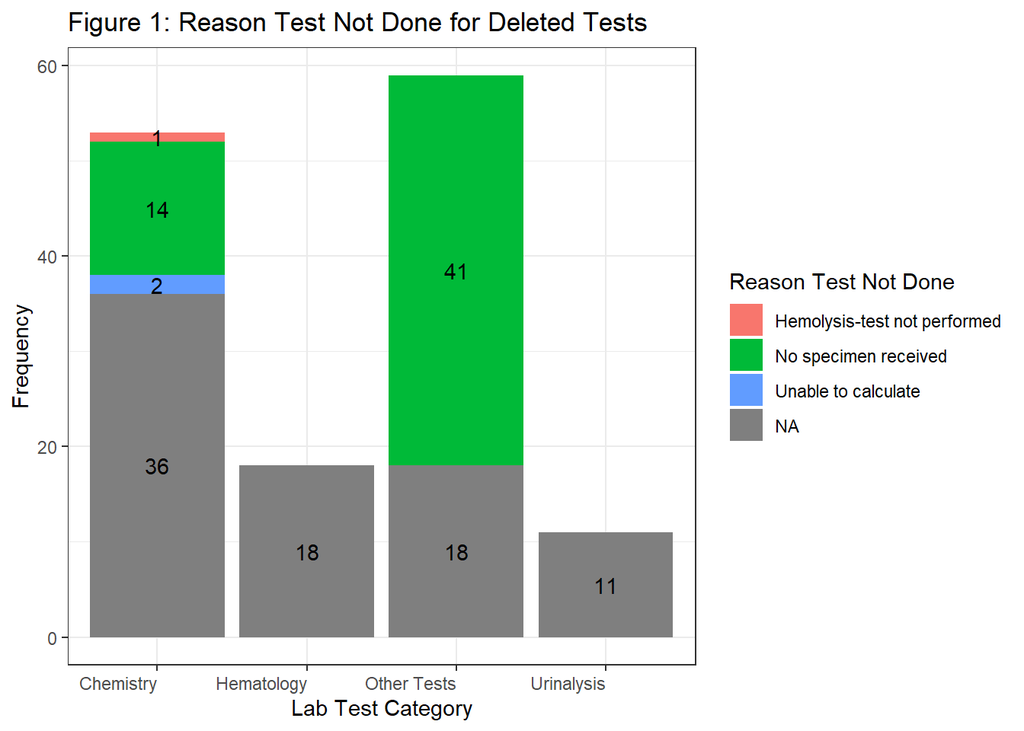

In general, reason for deletion entries are not consistently entered by Covance. The breakdown of deleted items with no reason specified, by visit is displayed in Figure 2.

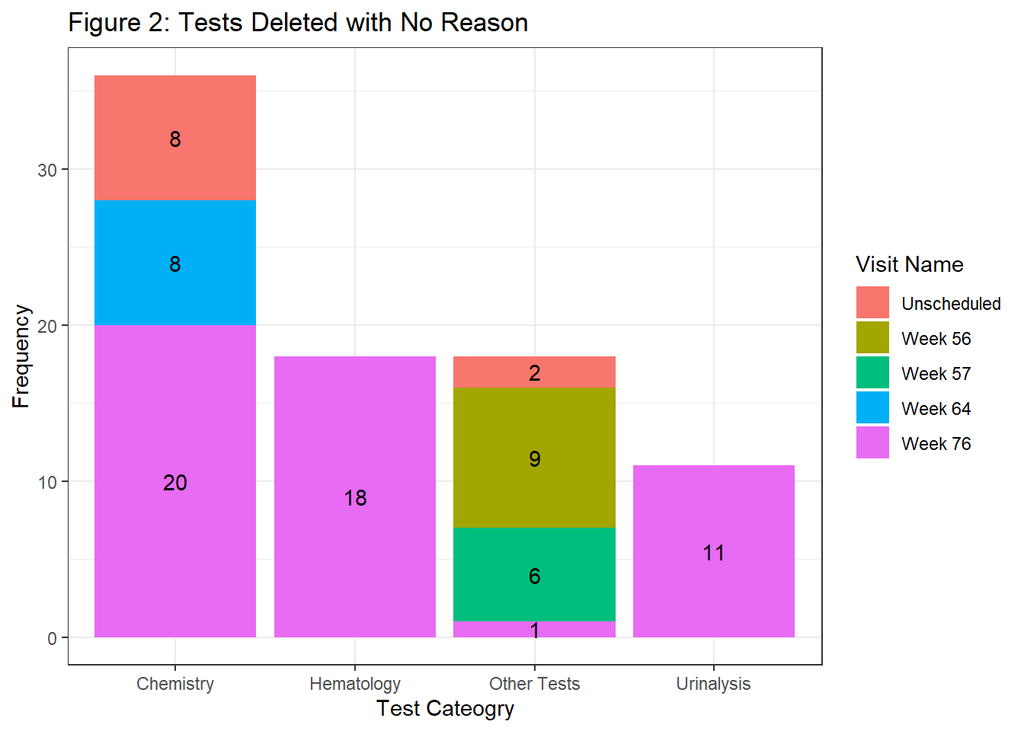

Test Names and associated frequencies of deleted tests in Figure 2 are displayed in Table 3.

Table 3: Deleted Tests with No Reason for Deletion

| Category.for.Lab.Test | Test.Name | n |
| --- | --- | --- |
| Chemistry | Alanine Aminotransferase | 3 |
| Chemistry | Albumin | 1 |
| Chemistry | Alkaline Phosphatase | 3 |
| Chemistry | Aspartate Aminotransferase | 3 |
| Chemistry | Bilirubin | 3 |
| Chemistry | Blood Urea Nitrogen | 1 |
| Chemistry | Calcium | 1 |
| Chemistry | Chloride | 1 |
| Chemistry | Cholesterol (High Performance) | 1 |
| Chemistry | Creatine Kinase | 1 |
| Chemistry | Creatinine | 1 |
| Chemistry | Direct Bilirubin | 3 |
| Chemistry | Gamma Glutamyl Transferase | 3 |
| Chemistry | Glucose (Non-Fasting) | 1 |
| Chemistry | Lactate Dehydrogenase | 2 |
| Chemistry | Liver DYSFUNCTION (TBIL) | 3 |
| Chemistry | Phosphate | 1 |
| Chemistry | Potassium | 1 |
| Chemistry | Protein | 1 |
| Chemistry | Sodium | 1 |
| Chemistry | Urate | 1 |
| Hematology | Basophil Count | 1 |
| Hematology | Basophils/Leukocytes | 1 |
| Hematology | Eosinophils | 1 |
| Hematology | Eosinophils/Leukocytes | 1 |
| Hematology | Ery. Mean Corpuscular Hemoglobin | 1 |
| Hematology | Ery. Mean Corpuscular Volume | 1 |
| Hematology | Erythrocytes | 1 |
| Hematology | Hematocrit | 1 |
| Hematology | Hemoglobin | 1 |
| Hematology | Leukocytes | 1 |
| Hematology | Lymphocytes | 1 |
| Hematology | Lymphocytes/Leukocytes | 1 |
| Hematology | Monocytes | 1 |
| Hematology | Monocytes/Leukocytes | 1 |
| Hematology | Neutrophils | 1 |
| Hematology | Neutrophils/Leukocytes | 1 |
| Hematology | Platelets | 1 |
| Hematology | RBC Morphology | 1 |
| Other Tests | Blood Viral Shedding CONF | 2 |
| Other Tests | Blood Viral Shedding Quantitative | 2 |
| Other Tests | Blood Viral Shedding SCR | 2 |
| Other Tests | C-Reactive Protein | 1 |
| Other Tests | FVIII Activity Chromogenic Expedited | 1 |
| Other Tests | FVIII Activity OSC Expedited | 1 |
| Other Tests | Saliva Viral Shedding CONF | 1 |
| Other Tests | Saliva Viral Shedding Quantitative | 1 |
| Other Tests | Saliva Viral Shedding SCR | 1 |
| Other Tests | Stool Viral Shedding CONF | 2 |
| Other Tests | Stool Viral Shedding Quantitative | 2 |
| Other Tests | Stool Viral Shedding SCR | 2 |
| Urinalysis | Color | 1 |
| Urinalysis | Specific Gravity | 1 |
| Urinalysis | Specimen Appearance | 1 |
| Urinalysis | Urine Bilirubin | 1 |
| Urinalysis | Urine Glucose | 1 |
| Urinalysis | Urine Ketones | 1 |
| Urinalysis | Urine Nitrite | 1 |
| Urinalysis | Urine Occult Blood | 1 |
| Urinalysis | Urine pH | 1 |
| Urinalysis | Urine Protein | 1 |
| Urinalysis | Urine Urobilinogen | 1 |

Frequency of deletion, by test, ranges from (min 1) to (max3) across 62 tests.

$$\\[0.5in]$$

### **Changed Category: New Test Results**

The study is in maintenance so new test results are expected. However, a number of new samples are reflected in the clinical programming comparison report. Figure 3 shows new lab tests, by category, for those samples whose sample date is on or before 20Dec2020.

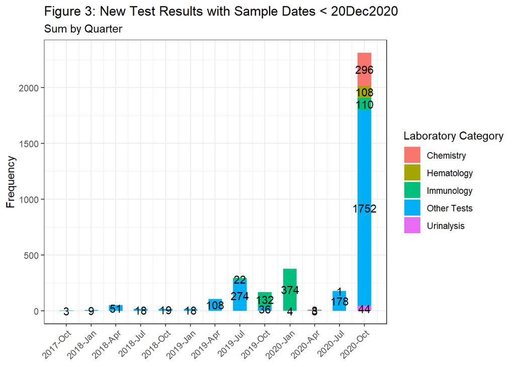

It is worth noting that many of the sample results dates differ significantly from the sample date.

Figure 3b shows the duration between when the sample was collected and when it was resulted. The linear nature of the line is expected because of the axis variables. The parallel lines in left upper portion of the plot suggest batch testing of some labs, which is expected. Of particular interest are those points in the bottom right which were collected and resulted prior to the TopLine snap, but are showing up as new results.

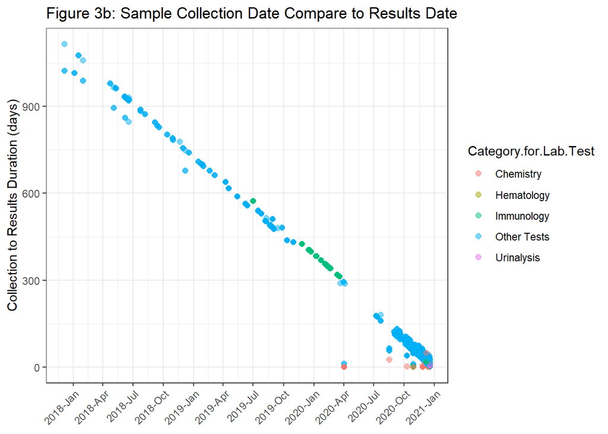

The input file with ‘New’ data was only recently made available so time constraints prevented further exploration. However, it is recommended that it be added to this analysis

### **Changed Variable: Laboratory Results Date**

There were 367 changes to laboratory result dates were observed. Figure 4 shows testing date changes occurred across two time periods; Period 1 = dates scattered across mid-2019; Period 2 = dates in late 2020 and early 2021.

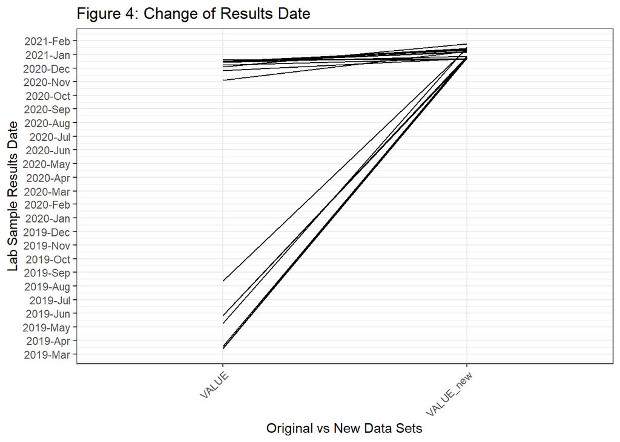

The “Values” labels on the x-axis in Figure 4 represents the Dec 2020 snap shot data and the “Values_new” label represents the current data (20210126). New testing date values range from 2020-12-22 to 2021-01-25

Figure 4 shows period 1 lab result updates (those results with original results dates spread across mid-2019). Most are associated with HLA results. Prior to the snapshot in December, it was discovered that some HLA tests were mapped incorrectly and other HLA tests were missing. This issue was addressed at Covance causing changes to be applied to these types of tests. It was expected that resolution of this issue would create some variables to change but it is unclear why the sample results date is changed.

One exception is noted: Blood Viral Shedding labs shown in Figure 5 were not included of the mapping and missing test updates.

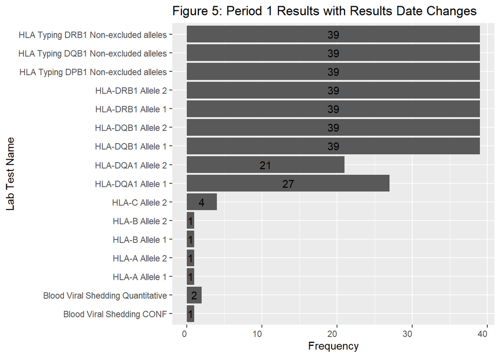

Figure 6 shows period 2 tests (those tests with original results dates at the end of 2020 and early 2021). These are spread across various lab categories and there is no apparent pattern.

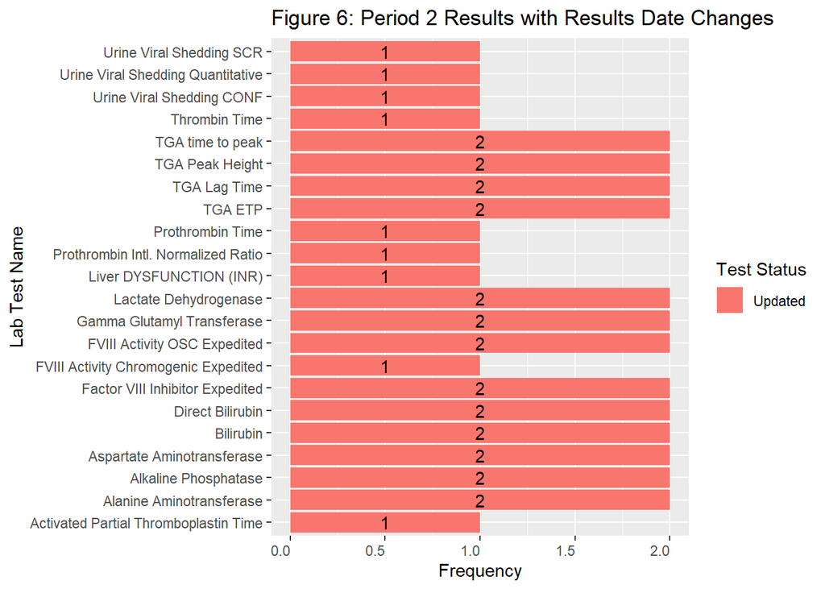

Details of findings in Figure 4 and 5 can be found in the accompanied data file entitled 270301_SnapShot_Compare_unroll20210126.csv file, by filtering “VARIABLE” column for LBRESDAT. Original and current values will be in the VALUE and VALUE_new columns, respectively.

$$\\[0.5in]$$

### **Changed Variable: Laboratory Results**

Using the original results variable (LBORRES), there were changes to results of 189 tests. A manual review of the changes to the results field shows three high-level categories

- Original value was NA and was updated to ‘See comment’
- Original result was blank and has been updated to contain a value
- Original result value does not match updated result value

#### Original value was NA and was updated to ‘See comment’

Figure 7, below shows all tests that originally had “NA” in the results field and now reflect ‘See Comment’. These are exclusively associated with HLA tests. Recent discussions with Covance have included a need to conform to the DTS regarding the use of “NA” in the results field. These updates may be due to actions taken by Covance related to these discussions.

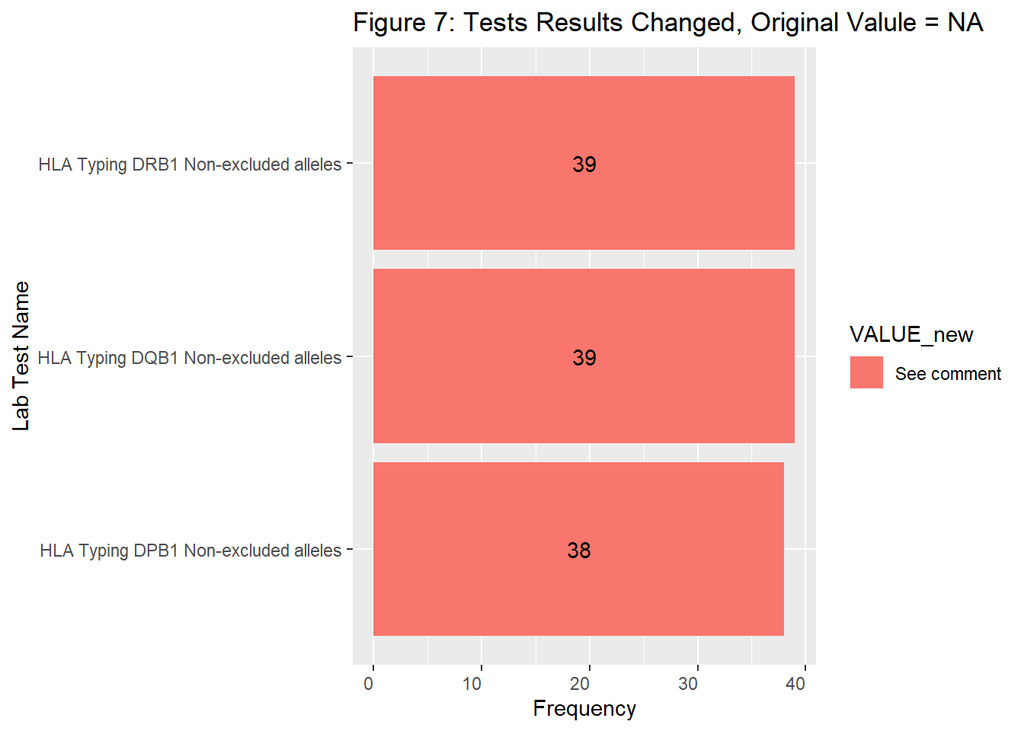

#### Original result was blank and has been updated to contain a value

Laboratory results that were null in the original snapshot data set, but now have results, are shown below in Figure 8, and a list of these subjects and lab tests are found in Table 4. Details can also be found in the accompanied data export file.

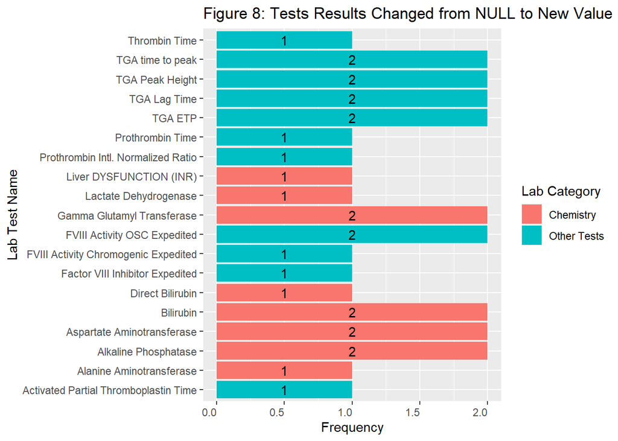

Table 4: Tests Results Changed, Original Valule Null (Detailed)

| Visit.Name | Test.Name | VALUE | VALUE_new |
| --- | --- | --- | --- |
| Week 122 | FVIII Activity OSC Expedited |  | 0.245 |
| Week 104 | TGA ETP |  | 1892 |
| Week 104 | TGA Lag Time |  | 6.5 |
| Week 104 | TGA Peak Height |  | 376.0 |
| Week 104 | TGA time to peak |  | 8.9 |
| Week 64 | Alkaline Phosphatase |  | 63 |
| Week 64 | Alanine Aminotransferase |  | 10 |
| Week 64 | Aspartate Aminotransferase |  | 16 |
| Week 64 | Direct Bilirubin |  | <2 |
| Week 64 | Bilirubin |  | 5 |
| Week 64 | Gamma Glutamyl Transferase |  | 17 |
| Week 48 | TGA ETP |  | 2138 |
| Week 48 | TGA Lag Time |  | 9.0 |
| Week 48 | TGA Peak Height |  | 514.0 |
| Week 48 | TGA time to peak |  | 11.3 |
| Week 60 | Alkaline Phosphatase |  | 60 |
| Week 60 | Aspartate Aminotransferase |  | 48 |
| Week 60 | Bilirubin |  | 7 |
| Week 60 | Gamma Glutamyl Transferase |  | 21 |
| Week 60 | Lactate Dehydrogenase |  | 161 |
| Week 56 | Activated Partial Thromboplastin Time |  | 32.9 |
| Week 56 | FVIII Activity Chromogenic Expedited |  | 0.210 |
| Week 56 | FVIII Activity OSC Expedited |  | 0.395 |
| Week 56 | Factor VIII Inhibitor Expedited |  | <0.6 |
| Week 56 | Prothrombin Intl. Normalized Ratio |  | 0.9 |
| Week 56 | Liver DYSFUNCTION (INR) |  | Criteria Not Met |
| Week 56 | Prothrombin Time |  | 9.9 |
| Week 56 | Thrombin Time |  | 16.9 |

#### Original result value does not match updated result value

The final group (results were updated and do not match original results) is shown in the figure below. These are primarily related to HLA testing and the change appears to be related to the addition of a suffix identifier at the end results string. SME knowledge would be needed to identify whether these suffixes substantially alter the results.

Table 5: Tests Results Changed, Original:New Mismatch

| Visit.Name | Test.Name | VALUE | VALUE_new |
| --- | --- | --- | --- |
| Screening | HLA-DRB1 Allele 1 | DRB1*01:01 | DRB1*01:01P |
| Screening | HLA-DRB1 Allele 2 | DRB1*04:01 | DRB1*04:01P |
| Screening | HLA-DQA1 Allele 1 | DQA1*01:03 | DQA1*01:03P |
| Screening | HLA-DQA1 Allele 2 | DQA1*04:01 | DQA1*04:01P |
| Screening | HLA-DRB1 Allele 1 | DRB1*08:02 | DRB1*08:02P |
| Screening | HLA-DRB1 Allele 2 | DRB1*08:03 | DRB1*08:03P |
| Screening | HLA-DQA1 Allele 2 | DQA1* | DQA1*01:01P |
| Week 3 | Blood Viral Shedding CONF | 10247865.00 | 114912782.81 |
| Week 3 | Blood Viral Shedding Quantitative | 363399.47 | 4074921.38 |
| Screening | HLA-DQA1 Allele 2 | DQA1*04:01 | DQA1*04:01P |
| Screening | HLA-B Allele 2 | B* | B*15 |
| Screening | HLA-C Allele 2 | C* | C*03 |
| Screening | HLA-DQA1 Allele 1 | DQA1*02:01 | DQA1*02:01P |
| Screening | HLA-DRB1 Allele 1 | DRB1*04:01 | DRB1*04:01P |
| Screening | HLA-DQA1 Allele 2 | DQA1*05:01 | DQA1*05:01P |
| Screening | HLA-DRB1 Allele 2 | DRB1*13:02 | DRB1*13:02P |
| Screening | HLA-DQA1 Allele 2 | DQA1*02:01 | DQA1*02:01P |
| Screening | HLA-DQA1 Allele 1 | DQA1*01:03 | DQA1*01:03P |
| Screening | HLA-DQA1 Allele 1 | DQA1*02:01 | DQA1*02:01P |
| Screening | HLA-DRB1 Allele 1 | DRB1*04:04 | DRB1*04:04P |
| Screening | HLA-DQA1 Allele 1 | DQA1*03:01 | DQA1*03:01P |
| Screening | HLA-DRB1 Allele 1 | DRB1*04:04 | DRB1*04:04P |
| Day 1 | Blood Viral Shedding Quantitative | 2678899384.62 | 26788993846.15 |
| Screening | HLA-DRB1 Allele 1 | DRB1*04:01 | DRB1*04:01P |
| Screening | HLA-DRB1 Allele 1 | DRB1*01:02 | DRB1*01:02P |
| Screening | HLA-DQA1 Allele 1 | DQA1*04:01 | DQA1*04:01P |
| Screening | HLA-C Allele 2 | C* | C*06 |
| Screening | HLA-C Allele 2 | C* | C*07 |
| Screening | HLA-DRB1 Allele 1 | DRB1*04:01 | DRB1*04:01P |
| Screening | HLA-DRB1 Allele 2 | DRB1*11:03 | DRB1*11:03P |
| Screening | HLA-DQA1 Allele 2 | DQA1*05:01 | DQA1*05:01P |
| Screening | HLA-DQA1 Allele 1 | DQA1*03:01 | DQA1*03:01P |
| Screening | HLA-DQA1 Allele 2 | DQA1*05:01 | DQA1*05:01P |
| Screening | HLA-DRB1 Allele 2 | DRB1*04:01 | DRB1*04:01P |
| Screening | HLA-DQA1 Allele 1 | DQA1*05:01 | DQA1*05:01P |
| Screening | HLA-DRB1 Allele 1 | DRB1*04:01 | DRB1*04:01P |
| Screening | HLA-DQA1 Allele 1 | DQA1*03:01 | DQA1*03:01P |
| Screening | HLA-DRB1 Allele 1 | DRB1*04:04 | DRB1*04:04P |
| Screening | HLA-DRB1 Allele 2 | DRB1*11:04 | DRB1*11:04P |
| Screening | HLA-DQA1 Allele 1 | DQA1*02:01 | DQA1*02:01P |
| Screening | HLA-DQA1 Allele 2 | DQA1*02:02 | DQA1*02:01P |
| Screening | HLA-DQA1 Allele 1 | DQA1*02:01 | DQA1*02:01P |
| Screening | HLA-DQA1 Allele 2 | DQA1*05:01 | DQA1*05:01P |
| Screening | HLA-DQA1 Allele 1 | DQA1*01:03 | DQA1*01:03P |
| Week 76 | Factor VIII Inhibitor Expedited | 1.3 | 1.2 |

Tests included in Table 5 that are not related to HLA testing are isolated in Table 6 and appear to have substantial changes to the results values, where ‘substantial’ is defined here to mean a quantitative change in the results.

Table 6: Non-HLA Tests Results Changed, Original:New Mismatch

| Visit.Name | Test.Name | VALUE | VALUE_new |
| --- | --- | --- | --- |
| Week 3 | Blood Viral Shedding CONF | 10247865.00 | 114912782.81 |
| Week 3 | Blood Viral Shedding Quantitative | 363399.47 | 4074921.38 |
| Day 1 | Blood Viral Shedding Quantitative | 2678899384.62 | 26788993846.15 |
| Week 76 | Factor VIII Inhibitor Expedited | 1.3 | 1.2 |

$$\\[0.5in]$$

### **Changed Variable: Laboratory Units**

All lab test unit changes (LBORRESU) are such that units in the original snapshot data were null but contain non-null values in the new data set. Table 7 shows each changed unit has an associated lab test change already described in the Laboratory Results section above, and suggesting these changes are functionally correlative.

Table 7: Test Units Changed (with Associated Results Change

| Visit.Name | Test.Name | Value_Unit | Value_new_Unit | Value_Result | Value_new_Result |
| --- | --- | --- | --- | --- | --- |
| Week 122 | FVIII Activity OSC Expedited |  | IU/mL |  | 0.245 |
| Week 104 | TGA ETP |  | nM x min |  | 1892 |
| Week 104 | TGA Lag Time |  | min |  | 6.5 |
| Week 104 | TGA Peak Height |  | nM |  | 376.0 |
| Week 104 | TGA time to peak |  | min |  | 8.9 |
| Week 64 | Alkaline Phosphatase |  | U/L |  | 63 |
| Week 64 | Alanine Aminotransferase |  | U/L |  | 10 |
| Week 64 | Aspartate Aminotransferase |  | U/L |  | 16 |
| Week 64 | Direct Bilirubin |  | umol/L |  | <2 |
| Week 64 | Bilirubin |  | umol/L |  | 5 |
| Week 64 | Gamma Glutamyl Transferase |  | U/L |  | 17 |
| Week 48 | TGA ETP |  | nM x min |  | 2138 |
| Week 48 | TGA Lag Time |  | min |  | 9.0 |
| Week 48 | TGA Peak Height |  | nM |  | 514.0 |
| Week 48 | TGA time to peak |  | min |  | 11.3 |
| Week 60 | Alkaline Phosphatase |  | U/L |  | 60 |
| Week 60 | Aspartate Aminotransferase |  | U/L |  | 48 |
| Week 60 | Bilirubin |  | umol/L |  | 7 |
| Week 60 | Gamma Glutamyl Transferase |  | U/L |  | 21 |
| Week 60 | Lactate Dehydrogenase |  | U/L |  | 161 |
| Week 56 | Activated Partial Thromboplastin Time |  | sec |  | 32.9 |
| Week 56 | FVIII Activity Chromogenic Expedited |  | IU/mL |  | 0.210 |
| Week 56 | FVIII Activity OSC Expedited |  | IU/mL |  | 0.395 |
| Week 56 | Factor VIII Inhibitor Expedited |  | BU/mL |  | <0.6 |
| Week 56 | Prothrombin Intl. Normalized Ratio |  | ratio |  | 0.9 |
| Week 56 | Prothrombin Time |  | sec |  | 9.9 |
| Week 56 | Thrombin Time |  | sec |  | 16.9 |

$$\\[0.5in]$$

### **Closing**

As previously mentioned, this report is accompanied with a file containing details of the changes identified in the clinical programming file. However, blinding procedures will dictate access to the file.

Only a subset of the changed variables were explored during this analysis. Exploration of additional variables can be done, if needed.